# Ćwiczenie 2 MongoDB

#### e) Określ, ile każde przedsiębiorstwo otrzymało wskazówek/napiwków (tip) w 2012. Wynik posortuj alfabetycznie według liczby (tip).

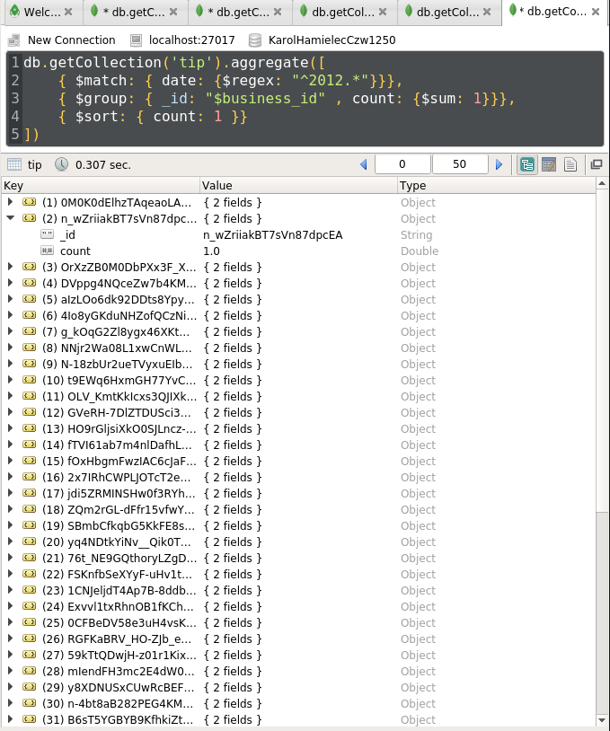

- ```javascript
  db.getCollection('tip').aggregate([
      { $match: { date: {$regex: "^2012.*"}}},
      { $group: { _id: "$business_id" , count: {$sum: 1}}},
      { $sort: { count: 1 }}
  ])
  ```

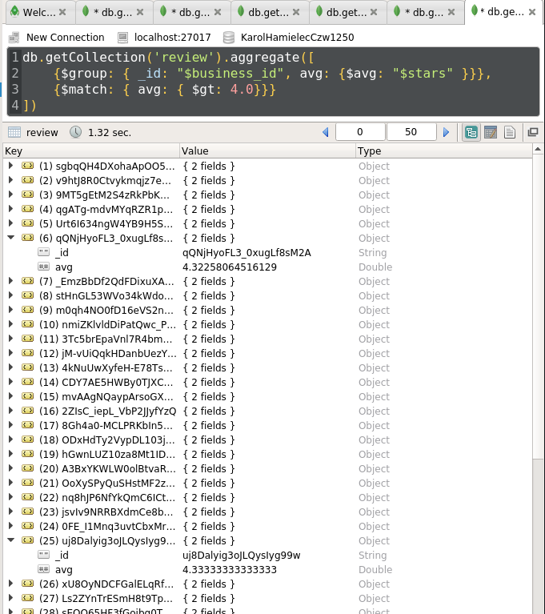

- ```javascript
  db.getCollection('review').aggregate([
      {$group: { _id: "$business_id", avg: {$avg: "$stars" }}},
      {$match: { avg: { $gt: 4.0}}}
  ])
  ```

#### g) Usuń́ wszystkie firmy (business), które posiadają̨ ocenę̨ (stars) równą 2.0.

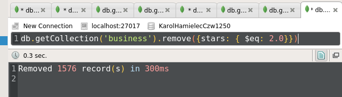

```javascript
  db.getCollection('business').remove({stars: { $eq: 2.0}})
```

## zad.2

Zdefiniuj funkcję (MongoDB) umożliwiającą dodanie nowej recenzji (review). Wykonaj przykładowe wywołanie.

```javascript
function addReview(votes, user_id, review_id, stars, date, text, type, business_id) {
    // write your code here
    db.review.insert({
    votes: votes,
    user_id: user_id,
    review_id: review_id,
    stars: stars,
    date: date,
    text: text,
    type: type,
    business_id: business_id
    });
}
addReview({ funny: 2}, 3, 3, 3, "2020-04-14", "testsetest", "xd", 211213)
```

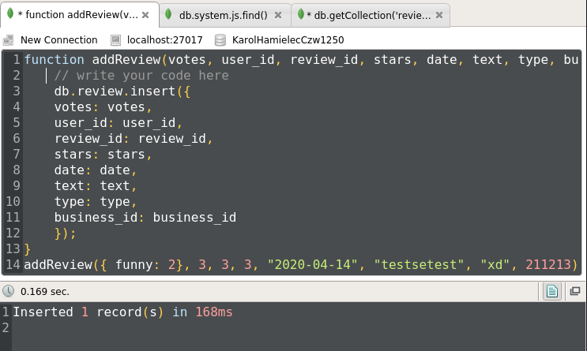

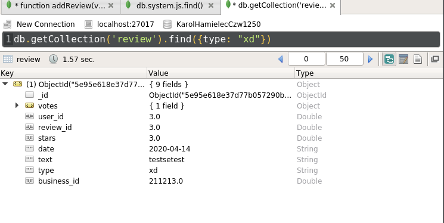

## zad.3

```javascript
function getBusinessWithCategory(cat) {
    // write your code here
    return db.business.find({ categories: cat});
}
getBusinessWithCategory("Food");
```

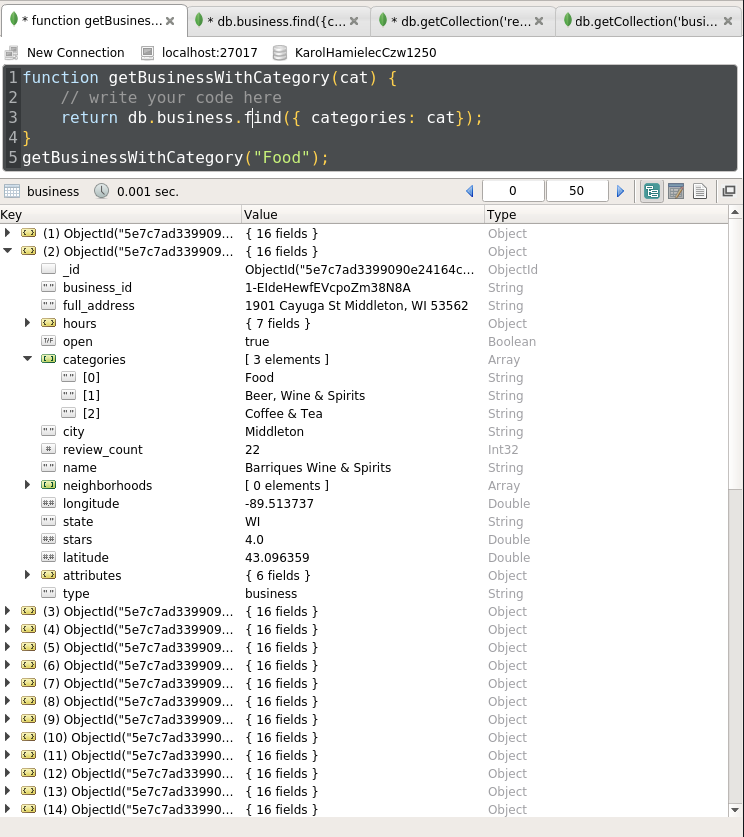

## zad.4

Zdefiniuj funkcję (MongoDB), która umożliwi modyfikację nazwy użytkownika (user) na podstawie podanego id. Id oraz nazwa mają być przekazywane jako parametry.

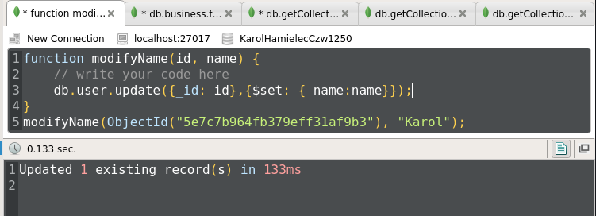

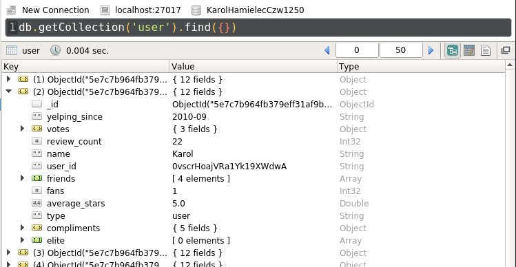

```javascript
function modifyName(id, name) {
    // write your code here
    db.user.update({_id: id},{$set: { name:name}});
}
modifyName(ObjectId("5e7c7b964fb379eff31af9b3"), "Karol");
```

## zad.5

Zwróć́ średnią ilość́ wszystkich wskazówek/napiwków dla każdego z biznesów, wykorzystaj map reduce.

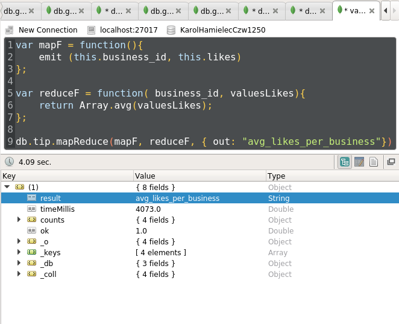

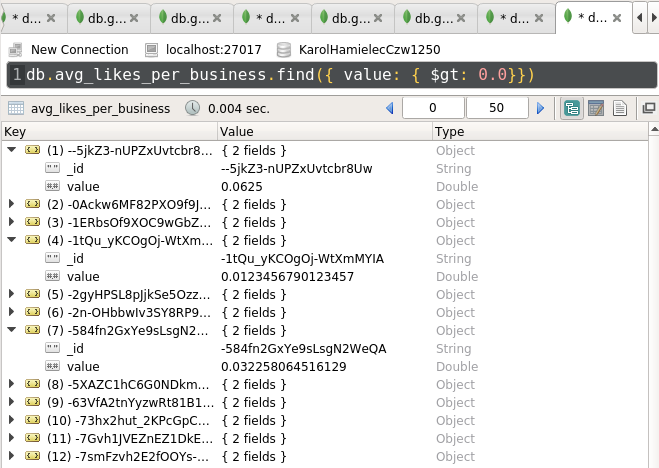

```javascript
var mapF = function(){
    emit (this.business_id, this.likes)
};

var reduceF = function( business_id, valuesLikes){
    return Array.avg(valuesLikes);
};

db.tip.mapReduce(mapF, reduceF, { out: "avg_likes_per_business"})
```

## zad.6

Odwzoruj wszystkie zadania z punktu 1 w języku programowania (np. JAVA) z pomocą̨ API do MongoDB. Wykorzystaj dla każdego zadania odrębną metodę̨

```python
import pymongo
from bson.son import SON
from bson.code import Code


def zada( client):
    return client['business'].aggregate([ { "$group": { "_id": "$city"}}, { "$sort": { "_id": 1}} ])

def zadb(client):
    return client['review'].aggregate([
        {'$addFields': { 'year': { '$year': {'$toDate': "$date"}}}},
        {'$match': {'year': {'$gte': 2011 } } },
        {'$group': { '_id': 'null', 'total': { '$sum': 1}}},
        {'$project': {'_id': 0}}
        ])

def zadc(client):
    return client['business'].find({'open': False}, { 'name': 1, 'full_address': 1, 'stars': 1})

def zadd(client):
    return client['user'].find({ '$or': [{'votes.funny': 0}, {'votes.useful': 0}] }).sort([( 'name', 1)])

def zade(client):
    return client['tip'].aggregate([
        { '$match': { 'date': { '$regex': "^2012.*"}}},
        { '$group': { "_id": "$business_id", "count": { '$sum': 1}}},
        { '$sort': { "count": 1}}
    ])

def zadf(client):
    return client['review'].aggregate([
        { '$group': { '_id': "$business_id", 'avg': { '$avg': "$stars" }}},
        { '$match': { 'avg': { '$gt': 4.0}}}])

def zadg(client):
    return client['business'].remove({ 'stars': { '$eq': 2.0 }})

if __name__ == '__main__':
    host = 'localhost'
    port =  27017
    db = 'KarolHamielecCzw1250'
    cl = pymongo.MongoClient( host, port)

    l2 = list(zadg(cl[db]))
    print(l2)
```

## zad.7

Kolekcja kienci:

```javascript
{
  name: "",
  email: "",
  phone_number: 123456789
  address: {
    city: ""
    street: ""
    postal_code: ""
  },
  created: "2020-02-02"
}
```

Kolekcja przedmioty:

```javascript
{
  name: "",
  price: 10.0
  avaiability: true
}
```

Kolekcja zakupy:

```javascript
{
  user_id: "",
  cart: [ { item_id: "", qty: 3 },
          { item_id: "", qty: 23 },
          { item_id: "", qty: 16 }],
  date: "2020-02-02",
  payment_made: "2020-02-03"
}
```